# k-NN Combine Data

[figure not shown]

## Classification: Predicting a player's position

### Summary:

The aim of this project is to classify football players by position groups based on physical characteristics.

An in-depth guide/tutorial on the methodology used for this project can be found [here](https://kevinzakka.github.io/2016/07/13/k-nearest-neighbor/)

Additional resources:

- [k-nearest neighbors algorithm - wikipedia](https://en.wikipedia.org/wiki/K-nearest_neighbors_algorithm)
- [Introduction to Machine Learning with Python: A Guide for Data Scientists](https://www.amazon.com/Introduction-Machine-Learning-Python-Scientists/dp/1449369413)

#### Terms used

- Class (label) - A predefined list of possiblities for a player to fit into, such as OL, DL, RB, etc.
- Target - Interchangeable with class.
- Samples - The individual players.
- Features - The variables that will be used to make our determination, in this case: player height, weight, arm length, hand size, and forty yard sprint time.
- Shape - The number of samples multiplied by the number of features.
- K (*Nearest Neighbors Algorithm*) - [See here](https://kevinzakka.github.io/2016/07/13/k-nearest-neighbor/#more-on-k)

#### Techonology used

- [Anaconda](https://www.continuum.io/anaconda-overview)
  - Jupyter
  - IPython

### *k*-nearest neighbors algorithm

The k-nearest neighbors algorithm is a non-parametric method used for classification and regression. In both cases, the input consists of *k* closest training examples in the feature space.

In our case, we are using k-NN for classification. The output is a class membership. An object is classified by a majority vote of its neighbors, with the object being assigned to the class most common near its *k* nearest neighbors (with *k* > 0). If *k*= 1, then the object is simply assigned to the class of that single nearest neighbor. For our purposes we are using the 15 nearest neighbors.

*k*-NN is a type of instance-based learning, where the function is only approximated locally and all computation is deferred until classification. This algorithm is among the simplest of all machine learning algorithms.

```python
# Standards imports
import numpy as np
import matplotlib.pyplot as plt
import pandas as pd
from IPython.display import set_matplotlib_formats, display
from sklearn.datasets import load_files
```

#### Importing data from a CSV File

We need to get data from a csv file into a workable format, so we use the numpy [loadtxt](https://docs.scipy.org/doc/numpy/reference/generated/numpy.loadtxt.html) function.

```python
all_data = np.loadtxt(open('./more_combine_combined_positions.csv','r'),
                     delimiter=',',
                     skiprows=0,
                     dtype=np.float64)
```

```python
# load class labels from column 1
y_data = all_data[:,0]
```

```python
# conversion of class labels to int array
y_data = y_data.astype(np.int64, copy=False)
```

```python
# Load the 5 features
X_data = all_data[:,1:]
```

```python
print('total number of samples (rows):', X_data.shape[0])
print('total number of features (columns):', X_data.shape[1])
```

```
total number of samples (rows): 1146
total number of features (columns): 5
```

### Relative frequency of the position groups

Here we give a breakdown of our samples in terms of proportion of the dataset.

```python
target_names = ['OL', 'DL', 'LB', 'DB', 'RB', 'WR/TE', 'QB']

print('Class label frequencies')
for i in range(0, len(target_names)):
    print('{} samples: {:.2%}'.format(target_names[i], list(y_data).count(i)/y_data.shape[0]))
```

```
Class label frequencies
OL samples: 15.45%
DL samples: 15.27%
LB samples: 11.78%
DB samples: 16.49%
RB samples: 10.38%
WR/TE samples: 24.87%
QB samples: 5.76%
```

#### Splitting the data

The given dataset is split into two sections, with 75% being *training data* and the remaining 25% being *test data*.

```python
# Combine previous data into a dictionary
combine_dataset = {}
combine_dataset['data'] = X_data
combine_dataset['target'] = y_data

# Set Target (Position) Names
combine_dataset['target_names'] = target_names
```

```python
# Call train_test_split on our data and assign outputs
from sklearn.model_selection import train_test_split

X_train, X_test, y_train, y_test = train_test_split(
    combine_dataset['data'], combine_dataset['target'],
    test_size=.25, train_size=.75, random_state=0)
```

##### Training and test data breakdown

The training data stored in *X_train* is 859 rows and 5 columns. Similarly, the *X_test* data is 287 rows and 5 columns.

```python
# Training data shape
print("X_train shape: {}".format(X_train.shape))

# Test data shape
print("X_test shape: {}".format(X_test.shape))
```

```
X_train shape: (859, 5)
X_test shape: (287, 5)
```

### Determining the optimal number of Neighbors to use in the classification

```python
from sklearn.model_selection import cross_val_score
from sklearn.neighbors import KNeighborsClassifier

myList = list(range(1,50))

neighbors = list(filter(lambda x: x % 2 != 0, myList))

cv_scores = []

for k in neighbors:
    knn = KNeighborsClassifier(n_neighbors=k, weights='distance')
    scores = cross_val_score(knn, X_data, y_data, cv=10, scoring='accuracy')
    cv_scores.append(scores.mean())

MSE = [1 - x for x in cv_scores]
optimal_k = neighbors[MSE.index(min(MSE))]
print("Optimal: {} (MSE: {:.4f})".format(optimal_k, min(MSE)))
```

```
Optimal: 15 (MSE: 0.3874)
```

#### Plotting the optimal K

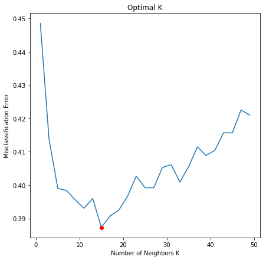

```python
plt.figure(figsize=(7,7))
plt.plot(neighbors, MSE)
plt.plot(optimal_k, min(MSE), 'ro')
plt.title('Optimal K')
plt.xlabel('Number of Neighbors K')
plt.ylabel('Misclassification Error')
plt.show()
```

#### Initialize k-NN with 15 neighbors, weighted for distance

-distance : weight points by the inverse of their distance. in this case, closer neighbors of a query point will have a greater influence than neighbors which are further away.

We use this instead of *uniform* weighting, which weights each point in a neighborhood equally.

```python
from sklearn.neighbors import KNeighborsClassifier
knn = KNeighborsClassifier(n_neighbors=15, weights='distance')
```

#### Building the model

To build the model on the training set, we call the fit method of the knn object, which takes as arguments the NumPy array *X_train* containing the training data and the NumPy array *y_train* of the corresponding training labels.

```python
knn.fit(X_train, y_train)
```

```
KNeighborsClassifier(algorithm='auto', leaf_size=30, metric='minkowski',
           metric_params=None, n_jobs=1, n_neighbors=15, p=2,
           weights='distance')
```

#### Testing the model with 2017 NFL Combine data

Below are 14 players (2 for each "position group") that have each participated in the 2017 NFL Combine. To ensure lack of bias, our training and test data relies on combine participants from 2016 and older.

|  | Name | Position | Height (in) | Weight (lb) | Arm Length (in) | Hand Size (in) | Forty Time (s) |
| --- | --- | --- | --- | --- | --- | --- | --- |
| 1 | Mitchell Trubinsky | QB | 74 | 222 | 32 | 9.5 | 4.67 |
| 2 | Patrick Mahomes | QB | 74 | 225 | 33.25 | 9.25 | 4.8 |
| 3 | Alvin Kamara | RB | 70 | 214 | 32.75 | 9.25 | 4.56 |
| 4 | Samaje Perine | RB | 71 | 233 | 30.375 | 10 | 4.65 |
| 5 | KD Cannon | WR | 71 | 182 | 30.75 | 8.875 | 4.41 |
| 6 | Ardarius Stewart | WR | 71 | 204 | 32.5 | 9.75 | 4.49 |
| 7 | Cam Robinson | OL | 78 | 322 | 35.5 | 10.5 | 5.15 |
| 8 | Pat Elflein | OL | 75 | 303 | 33.25 | 9.75 | 5.32 |
| 9 | Charles Harris | DL | 75 | 253 | 32.375 | 9.625 | 4.82 |
| 10 | Jonathan Allen | DL | 75 | 286 | 33.625 | 9.375 | 5.00 |
| 11 | Jabrill Peppers | LB | 71 | 213 | 30.75 | 9.625 | 4.46 |
| 12 | Ryan Anderson | LB | 74 | 253 | 31.5 | 9.375 | 4.78 |
| 13 | Marlon Humphrey | DB | 72 | 197 | 32.25 | 8.75 | 4.41 |
| 14 | Jamal Adams | DB | 72 | 214 | 33.375 | 9.25 | 4.56 |

#### Creation of the player matrix

```python
playerMx = [
         ['Mitchell Trubinsky', 'QB', [74, 222, 32, 9.5, 4.67]],
         ['Patrick Mahomes', 'QB', [74,225,33.25,9.25,4.8]],
         ['Alvin Kamara', 'RB', [70,214,32.75,9.25,4.56]],
         ['Samaje Perine', 'RB', [71,233,30.375,10,4.65]],
         ['KD Cannon', 'WR/TE', [71,182,30.75,8.875,4.41]],
         ['Ardarius Stewart', 'WR/TE', [71,204,32.5,9.75,4.49]],
         ['Cam Robinson', 'OL', [78,322,35.5,10.5,5.15]],
         ['Pat Elflein', 'OL', [75,303,33.25,9.75,5.32]],
         ['Charles Harris', 'DL', [75,253,32.375,9.625,4.82]],
         ['Jonathan Allen', 'DL', [75,286,33.625,9.375,5]],
         ['Jabrill Peppers', 'LB', [71,213,30.75,9.625,4.46]],
         ['Ryan Anderson', 'LB', [74,253,31.5,9.375,4.78]],
         ['Marlon Humphrey', 'DB', [72,197,32.25,8.75,4.41]],
         ['Jamal Adams', 'DB', [72,214,33.375,9.25,4.56]]
     ]
```

#### Getting the predictions for each player and the associated position prediction probabilities

```python
playerPred = list()

# Get predictions and prediction probabilities
for pl in playerMx:
    newPlayer = np.array([pl[2]])  # Create NumPy array with physical attribute data
    newPrediction = knn.predict(newPlayer) # Generate prediction
    newProba = knn.predict_proba(newPlayer) # Generate prediction probabilities
    playerPred.append([pl[0], pl[1], newPrediction, newProba.tolist()[0]]) # Append Name, Pos, Pred, Proba to list
```

#### Printing out the results

```python
# counter for incorrect predictions
incorrect = 0

print("Results >>")
print("=" * 40, end='\n\n')

# Loops through the playerPred list to print out name, pos, prediction, possibilities
for pl in playerPred:

    print("{} - Actual Pos: {} | Predicted Pos: {}".format(pl[0], pl[1], combine_dataset['target_names'][pl[2]]),
          end="\n\t - Prediction:  ")
    if (pl[1] == combine_dataset['target_names'][pl[2]]):
        print(">> Correct <<")
    else:
        print("Incorrect")
        incorrect += 1
    # Print probabilities
    for i in range(0, len(pl[3])):
        if pl[3][i] > 0:
            print(" -", end= " ")
            print("{}: {:.2%}".format(combine_dataset['target_names'][i], pl[3][i]), end= "  ")
    print('\n')
```

```
Results >>
========================================

Mitchell Trubinsky - Actual Pos: QB | Predicted Pos: QB
	 - Prediction:  >> Correct <<
 - DB: 29.54%   - WR/TE: 32.52%   - QB: 37.93%

Patrick Mahomes - Actual Pos: QB | Predicted Pos: QB
	 - Prediction:  >> Correct <<
 - LB: 9.40%   - DB: 9.85%   - RB: 7.15%   - WR/TE: 30.07%   - QB: 43.54%

Alvin Kamara - Actual Pos: RB | Predicted Pos: RB
	 - Prediction:  >> Correct <<
 - DB: 38.63%   - RB: 61.37%

Samaje Perine - Actual Pos: RB | Predicted Pos: RB
	 - Prediction:  >> Correct <<
 - LB: 47.63%   - RB: 52.37%

KD Cannon - Actual Pos: WR/TE | Predicted Pos: WR/TE
	 - Prediction:  >> Correct <<
 - DB: 44.59%   - WR/TE: 55.41%

Ardarius Stewart - Actual Pos: WR/TE | Predicted Pos: WR/TE
	 - Prediction:  >> Correct <<
 - DB: 19.66%   - RB: 21.10%   - WR/TE: 59.24%

Cam Robinson - Actual Pos: OL | Predicted Pos: OL
	 - Prediction:  >> Correct <<
 - OL: 89.23%   - DL: 10.77%

Pat Elflein - Actual Pos: OL | Predicted Pos: OL
	 - Prediction:  >> Correct <<
 - OL: 61.01%   - DL: 38.99%

Charles Harris - Actual Pos: DL | Predicted Pos: WR/TE
	 - Prediction:  Incorrect
 - DL: 9.57%   - LB: 34.86%   - WR/TE: 55.57%

Jonathan Allen - Actual Pos: DL | Predicted Pos: DL
	 - Prediction:  >> Correct <<
 - DL: 100.00%

Jabrill Peppers - Actual Pos: LB | Predicted Pos: RB
	 - Prediction:  Incorrect
 - DB: 27.59%   - RB: 67.14%   - QB: 5.26%

Ryan Anderson - Actual Pos: LB | Predicted Pos: LB
	 - Prediction:  >> Correct <<
 - DL: 4.92%   - LB: 57.27%   - WR/TE: 37.81%

Marlon Humphrey - Actual Pos: DB | Predicted Pos: WR/TE
	 - Prediction:  Incorrect
 - DB: 47.16%   - WR/TE: 52.84%

Jamal Adams - Actual Pos: DB | Predicted Pos: DB
	 - Prediction:  >> Correct <<
 - DB: 50.50%   - RB: 25.26%   - WR/TE: 16.90%   - QB: 7.34%
```

##### Write to CSV

```python
with open('results.csv', 'w') as file:
    file.write('Name,Actual Pos,Predicted Pos,Prediction,Pos1,Pos1 Percent,Pos2,Pos2 Percent,Pos3,Pos3 Percent,Pos4,Pos4 Percent,Pos5,Pos5 Percent')
    file.write('\n')
    for pl in playerPred:
        line = str(pl[0]) + "," + str(pl[1]) + "," + str(combine_dataset['target_names'][pl[2]]) + ","
        if (pl[1] == combine_dataset['target_names'][pl[2]]):
            line += "Correct,"
        else:
            line += "Incorrect,"

        # Print probabilities
        for i in range(0, len(pl[3])):
            if pl[3][i] > 0:
                line += str(combine_dataset['target_names'][i]) + "," + str(pl[3][i]) + ","

        file.write(line)
        file.write('\n')
```

##### Overall Accuracy

```python
# Print summary
print(">> Correct: {} | Incorrect: {} | ({:.2%}) accuracy"
      .format(len(playerPred)-incorrect, incorrect,
        (len(playerPred)-incorrect)/len(playerPred)))
```

```
>> Correct: 11 | Incorrect: 3 | (78.57%) accuracy
```

### Evaluating the Model

To test the accuracy of our model, we will use the test dataset that we set aside earlier. As with the player data above, we use the *knn* predict method to test the entire *X_test* set.

##### Test set Predictions

Below the position predictions for each player in the *X_test* can be seen. The number corresponds to a position group. For example 0 indicates offensive linesman.

```python
y_pred = knn.predict(X_test)
print("Test set predictions: \n{}".format(y_pred))
```

```
Test set predictions:
[5 3 3 1 3 4 0 5 3 1 4 5 0 4 3 0 5 3 0 1 0 5 4 2 1 3 5 4 5 4 2 0 4 3 2 3 1
 2 5 2 5 5 5 5 3 6 5 3 3 3 3 5 2 0 0 4 0 1 3 1 4 3 5 1 6 5 6 0 0 2 5 3 0 1
 0 0 2 3 5 3 3 5 4 0 1 1 1 1 3 5 6 3 0 1 0 2 1 5 1 2 2 3 0 5 0 0 3 0 2 5 1
 3 2 1 0 1 2 4 4 0 4 5 5 4 2 1 2 6 1 2 4 4 6 2 4 2 5 0 5 5 3 5 1 5 0 5 2 0
 6 3 0 5 2 3 1 5 5 6 3 3 2 4 3 5 3 0 6 2 0 5 1 2 2 5 4 3 1 0 5 0 0 3 2 3 0
 3 3 3 2 0 3 5 3 3 0 4 3 3 5 3 1 3 0 2 0 2 5 0 2 6 5 0 3 5 2 5 5 0 3 5 0 4
 5 2 0 2 0 0 5 2 1 5 0 1 6 1 0 0 5 5 4 5 3 3 1 0 6 5 0 6 0 4 1 2 0 3 5 0 4
 5 0 2 5 1 1 0 5 0 0 0 1 2 2 5 0 3 2 4 3 3 5 5 2 5 5 0 5]
```

##### Test Score

Below, the *test set score* is displayed as a percentage. This score indicates the accuracy of the predictions made above using the *X_test* data. It is the mean accuracy on the given test data and labels (position groups).

```python
print("Test set score: {:.4%}".format(knn.score(X_test, y_test)))
```

```
Test set score: 60.6272%
```

## Moving Forward

#### Applying this model to high school recruiting data

Given a data set with similar features (weight, height, arm length, hand size, forty speed) using high school recruits rather than NFL combine data, we may be able to give more insight into the position that may best fit a new recruit.